# Estimating Impact of Weather on Public Health and Economy from NOAA Dataset

Bojan Zunar

22 June 2018

# 1 Summary

We explore U.S. National Oceanic and Atmospheric Administration’s (NOAA) storm database. The targeted database lists characteristics of major storms and weather events in the United States. Our analysis shows that temperature extremes (e.g. extreme heat, winter weather mix) and severe storm events (e.g. hurricane/typhoon) cause the most damage, both in terms of population health and material damage. Therefore, any policy-making should adequately allocate available resources.

# 2 Data Processing

Data were obtained from Coursera’s Reproducible Research webpage on the 21st June 2018 as a comma-separated-value file compressed via the bzip2 algorithm (https://d396qusza40orc.cloudfront.net/repdata%2Fdata%2FStormData.csv.bz2). Required CRAN packages were loaded into R.

```r
url = c("https://d396qusza40orc.cloudfront.net/repdata%2Fdata%2FStormData.csv.bz2")
dest = c("storms.csv.bz2")
# download.file(url, dest)  #uncomment if you wish to download data [47 Mb]

library(data.table); library(dplyr); library(ggplot2); library(ggrepel); library(ggsci);  library(magrittr); library(R.utils); library(reshape2); library(stringr)
```

The data were uncompressed and loaded into R using `fread` function of the `data.table` package, which greatly expedited processing of the dataset.

```r
bunzip2("storms.csv.bz2", remove = FALSE, skip = TRUE)
storms <- fread("storms.csv")
```

# 3 Data Transformations

The following section details data transformations used to estimate the effect of event types on population health. Next, we present the code used to estimate the impact of event types on the economy, but with much scantier description.

## 3.1 Event Types and Population Health

Relevant data were subsetted and transformed according to the “tidy data” philosophy.

```r
health.subset <- storms %>%
    rename_all(tolower) %>%
    mutate(evtype = tolower(evtype)) %>%
    select(evtype, fatalities, injuries) %>%
    melt(variable.name = "effect",
         value.name = "casualty",
         id.vars = "evtype")
```

Exploratory analysis showed that majority of the recorded events (> 98%) did not affect population health, i.e. they did not produce injuries or fatalities. More than half of the remaining events counted just a single casualty.

```r
health.subset %>% filter(casualty == 0) %>% nrow(.)/nrow(health.subset)
```

```
## [1] 0.9863803
```

```r
health.subset %>% filter(casualty == 1) %>% nrow(.)/nrow(health.subset)
```

```
## [1] 0.007074167
```

```r
health.subset %>% filter(casualty >1) %>% nrow(.)/nrow(health.subset)
```

```
## [1] 0.006545517
```

Therefore, we constructed special dataframe which indicated whether one event (TRUE) or more events (FALSE) within each event type caused damage.

```r
casualties <- health.subset %>%
    filter(casualty != 0) %>%
    group_by(evtype, effect) %>%
    summarise(events.with.casualties = n()) %>%
    mutate(events.with.casualties.is.1 = if_else(events.with.casualties == 1, TRUE, FALSE))
```

We created a new dataframe `health` which summarised events based on their type. For each type of event, it calculated the mean number of injuries and fatalities (mean), as well as the total number of injuries and fatalities (sum). We also calculated the 90th quantile to exclude the effect of outliers (uncommonly disruptive events/storms). Median and maximal values for each event type failed to uncover new insights (not shown). Created dataframe also included information on how often event types cause injuries and fatalities (proportion).

```r
health <- health.subset %>%
    group_by(evtype, effect) %>%
    summarise(mean = mean(casualty),
              median = median(casualty),
              max = max(casualty),
              sum = sum(casualty),
              q90 = quantile(casualty, 0.9),
              proportion = 1 - mean(!casualty, na.rm = TRUE)) %>%
    left_join(., casualties, by = c("evtype", "effect"))

rm(casualties, health.subset)
```

### 3.1.1 Labels

For convenience, figures that describe the analysis include labelled points for the most disruptive event types. We define these labels in additional columns of the `health` dataframe.

```r
health %<>%
    mutate(mean.label = case_when(mean > 4 & events.with.casualties.is.1 == FALSE ~ evtype)) %>%
    mutate(sum.label = case_when((sum > 1500 & events.with.casualties.is.1 == FALSE) | (proportion > 0.5 & proportion < 1 & sum > 100 & events.with.casualties.is.1 == FALSE) ~ evtype)) %>%
    mutate(q90.label = case_when(q90 > 8 & events.with.casualties.is.1 == FALSE ~ evtype))
```

### 3.1.2 multiplot() Function

We estimate of event types on population health on a three-facet figure generated in ggplot2, with the help of ‘multiplot()’ function (adopted from http://www.cookbook-r.com/Graphs/Multiple_graphs_on_one_page_(ggplot2)/).

```r
multiplot <- function(..., plotlist=NULL, file, cols=1, layout=NULL) {
    library(grid)

    # Make a list from the ... arguments and plotlist
    plots <- c(list(...), plotlist)

    numPlots = length(plots)

    # If layout is NULL, then use 'cols' to determine layout
    if (is.null(layout)) {
        # Make the panel
        # ncol: Number of columns of plots
        # nrow: Number of rows needed, calculated from # of cols
        layout <- matrix(seq(1, cols * ceiling(numPlots/cols)),
                         ncol = cols, nrow = ceiling(numPlots/cols))
    }

    if (numPlots==1) {
        print(plots[[1]])

    } else {
        # Set up the page
        grid.newpage()
        pushViewport(viewport(layout = grid.layout(nrow(layout), ncol(layout))))

        # Make each plot, in the correct location
        for (i in 1:numPlots) {
            # Get the i,j matrix positions of the regions that contain this subplot
            matchidx <- as.data.frame(which(layout == i, arr.ind = TRUE))

            print(plots[[i]], vp = viewport(layout.pos.row = matchidx$row,
                                            layout.pos.col = matchidx$col))
        }
    }
}
```

### 3.1.3 Figures

The following code generates three ggplot2 facets that show which event types most commonly produce casualties and how many casualties they produce.

```r
## plot health data: mean
plot.health.mean <- ggplot(health, aes(proportion, mean)) +
    geom_point(aes(colour = events.with.casualties.is.1, shape = effect, size = effect)) +
    geom_rug() +
    geom_text_repel(aes(label = mean.label),
                    box.padding   = 0.4,
                    point.padding = 0.5,
                    vjust = 1,
                    nudge_x = 0.05,
                    segment.color = "grey50") +
    labs(title = "Mean") +
    labs(x = "Proportion of events with casualties") +
    labs(y = "# of casualties") +
    theme_bw() +
    theme(legend.position = "none") +
    scale_colour_manual(name  = "# of events with casualties",
                        values = c(pal_npg("nrc")(2)[1],
                                   pal_npg("nrc", alpha = 0.2)(2)[1],
                                   pal_npg("nrc", alpha = 0.1)(2)[1]),
                        labels = c(">1", "1", "0")) +
    scale_shape_manual(values = c(16, 1),
                       labels = c("fatalities", "injuries")) +
    scale_size_manual(values = c(4, 3))

## plot health data: sum
plot.health.sum <- ggplot(health, aes(proportion, log10(sum))) +
    geom_point(aes(colour = events.with.casualties.is.1, shape = effect, size = effect)) +
    geom_rug() +
    geom_text_repel(aes(label = sum.label),
                    box.padding   = 0.4,
                    point.padding = 0.5,
                    hjust = 0,
                    segment.color = "grey50",
                    nudge_x = 0.1) +
    labs(title = "Sum per type of event") +
    labs(x = "Proportion of events with casualties") +
    labs(y = "Log10 of total casualties") +
    theme_bw() +
    theme(legend.position = "none") +
    scale_colour_manual(name  = "# of events with casualties",
                        values = c(pal_npg("nrc")(2)[1],
                                   pal_npg("nrc", alpha = 0.2)(2)[1],
                                   pal_npg("nrc", alpha = 0.1)(2)[1]),
                        labels = c(">1", "1", "0")) +
    scale_shape_manual(values = c(16, 1),
                       labels = c("fatalities", "injuries")) +
    scale_size_manual(values = c(4, 3))

## plot health data: q90
plot.health.q90 <- ggplot(health, aes(proportion, q90)) +
    geom_point(aes(colour = events.with.casualties.is.1, shape = effect, size = effect)) +
    geom_rug() +
    geom_text_repel(aes(label = q90.label),
                    box.padding   = 0.4,
                    point.padding = 0.5,
                    hjust = 0,
                    vjust = 1,
                    segment.color = "grey50") +
    labs(title = "90th Quantile") +
    labs(x = "Proportion of events with casualties") +
    labs(y = "# of casualties") +
    theme_bw() +
    theme(legend.position = "bottom") +
    scale_colour_manual(name  = "# of events with casualties",
                        values = c(pal_npg("nrc")(2)[1],
                                   pal_npg("nrc", alpha = 0.2)(2)[1],
                                   pal_npg("nrc", alpha = 0.1)(2)[1]),
                        labels = c(">1", "1", "0")) +
    scale_shape_manual(values = c(16, 1),
                       labels = c("fatalities", "injuries")) +
    scale_size_manual(values = c(4, 3)) +
    ylim(c(0,50)) +
    guides(colour = guide_legend(override.aes = list(size = 5)),
           shape = guide_legend(override.aes = list(size = 5)))
```

## 3.2 Event Types and Economy

Relevant data were once again subsetted and transformed according to the “tidy data” philosophy. We generated new variables that were much more suitable for further analysis (e.g. we multiplied propdmg and propdmgexp cells to obtain final amount of damage generated per event).

```r
damage.subset <- storms %>%
    rename_all(tolower) %>%
    mutate(evtype = tolower(evtype)) %>%
    select(evtype, propdmg, propdmgexp, cropdmg, cropdmgexp) %>%
    mutate(propdmgexp = str_replace_all(propdmgexp, c("K" = "1000",
                                                      "M" = "1000000",
                                                      "B" = "1000000000",
                                                      "^$" = "0"))) %>%
    mutate(cropdmgexp = str_replace_all(cropdmgexp, c("K" = "1000",
                                                      "M" = "1000000",
                                                      "B" = "1000000000",
                                                      "^$" = "0"))) %>%
    mutate(propdmg = propdmg * as.numeric(propdmgexp)) %>%
    mutate(cropdmg = cropdmg * as.numeric(cropdmgexp)) %>%
    select(evtype, property = propdmg, crop = cropdmg) %>%
    melt(variable.name = "economy",
         value.name = "money",
         id.vars = "evtype")
```

Exploratory analysis showed that majority of the recorded events (> 85%) did not produce any damage.

```r
damage.subset %>% filter(money == 0) %>% nrow(.)/nrow(damage.subset)
```

```
## [1] 0.8553758
```

```r
damage.subset %>% filter(money >0) %>% nrow(.)/nrow(damage.subset)
```

```
## [1] 0.1445926
```

Once again, we constructed special dataframe which indicated whether one event (TRUE) or more events (FALSE) within each event type caused damage.

```r
money <- damage.subset %>%
    filter(money != 0) %>%
    group_by(evtype, economy) %>%
    summarise(events.with.damage = n()) %>%
    mutate(events.with.damage.is.1 = if_else(events.with.damage == 1, TRUE, FALSE))
```

We created a new dataframe `damage` which summarised events based on their type.

```r
damage <- damage.subset %>%
    group_by(evtype, economy) %>%
    summarise(mean = mean(money, na.rm = TRUE),
              median = median(money, na.rm = TRUE),
              max = max(money, na.rm = TRUE),
              sum = sum(money, na.rm = TRUE),
              q90 = quantile(money, 0.9, na.rm = TRUE),
              proportion = 1 - mean(!money, na.rm = TRUE)) %>%
    left_join(., money, by = c("evtype", "economy"))

rm(money, damage.subset)
```

### 3.2.1 Labels

```r
damage %<>%
    mutate(mean.label = case_when(mean > 10^7.8 & events.with.damage.is.1 == FALSE ~ evtype)) %>%
    mutate(sum.label = case_when(sum > 10^9.8 & events.with.damage.is.1 == FALSE ~ evtype)) %>%
    mutate(q90.label = case_when(q90 > 10^7.8 & events.with.damage.is.1 == FALSE ~ evtype))
```

### 3.2.2 Figures

The following code generates three ggplot2 facets that show which how often event types produce damage.

```r
## plot damage data: mean
plot.damage.mean <- ggplot(damage, aes(proportion, log10(mean))) +
    geom_point(size = 3, aes(colour = events.with.damage.is.1, shape = economy)) +
    geom_rug() +
    geom_text_repel(aes(label = mean.label),
                    box.padding   = 0.5,
                    point.padding = 0.5,
                    segment.color = "grey50") +
    labs(title = "Mean") +
    labs(x = "Proportion of events that ended in damage") +
    labs(y = "Log10 of USD") +
    theme_bw() +
    theme(legend.position = "none") +
    scale_colour_manual(name  = "# of events with damage",
                        values = c(pal_npg("nrc")(2)[2],
                                   pal_npg("nrc", alpha = 0.2)(2)[2],
                                   pal_npg("nrc", alpha = 0.1)(2)[2]),
                        labels = c(">1", "1", "0")) +
    scale_shape_manual(values = c(16, 1),
                       labels = c("property", "crop"))


## plot damage data: sum
plot.damage.sum <- ggplot(damage, aes(proportion, log10(sum))) +
    geom_point(size = 3, aes(colour = events.with.damage.is.1, shape = economy)) +
    geom_rug() +
    geom_text_repel(aes(label = sum.label),
                    box.padding   = 0.5,
                    point.padding = 0.5,
                    segment.color = "grey50") +
    labs(title = "Sum per type of event") +
    labs(x = "Proportion of events that ended in damage") +
    labs(y = "Log10 of USD") +
    theme_bw() +
    theme(legend.position = "none") +
    scale_colour_manual(name  = "# of events with damage",
                        values = c(pal_npg("nrc")(2)[2],
                                   pal_npg("nrc", alpha = 0.2)(2)[2],
                                   pal_npg("nrc", alpha = 0.1)(2)[2]),
                        labels = c(">1", "1", "0")) +
    scale_shape_manual(values = c(16, 1),
                       labels = c("property", "crop"))


## plot damage data: q90
plot.damage.q90 <- ggplot(damage, aes(proportion, log10(q90))) +
    geom_point(size = 3, aes(colour = events.with.damage.is.1, shape = economy)) +
    geom_rug() +
    geom_text_repel(aes(label = q90.label),
                    box.padding   = 0.5,
                    point.padding = 0.5,
                    segment.color = "grey50") +
    labs(title = "90th Quantile") +
    labs(x = "Proportion of events that ended in damage") +
    labs(y = "Log10 of USD") +
    theme_bw() +
    theme(legend.position = "bottom") +
    scale_colour_manual(name  = "# of events with damage",
                        values = c(pal_npg("nrc")(2)[2],
                                   pal_npg("nrc", alpha = 0.2)(2)[2],
                                   pal_npg("nrc", alpha = 0.1)(2)[2]),
                        labels = c(">1", "1", "0")) +
    scale_shape_manual(values = c(16, 1),
                       labels = c("property", "crop")) +
    guides(colour = guide_legend(override.aes = list(size = 5)),
           shape = guide_legend(override.aes = list(size = 5)))
```

# 4 Results

## 4.1 Event Types and Population Health

We generated three graphs to summarise the effect of event types on population health. On the x-axis, the graphs show how often a specific type of event ends in casualties. For example, if each event of a particular type always produces casualties, it will be placed on the right end of the axis and will have the probability of 1. The y-axes show either total or mean number of casualties type events produced, as well as 90th quantile for each type of event. The last metric excludes events within the event type that produced the top 10% casualties to eliminate outliers, i.e. uncommon events that have generated an inordinately large number of casualties.

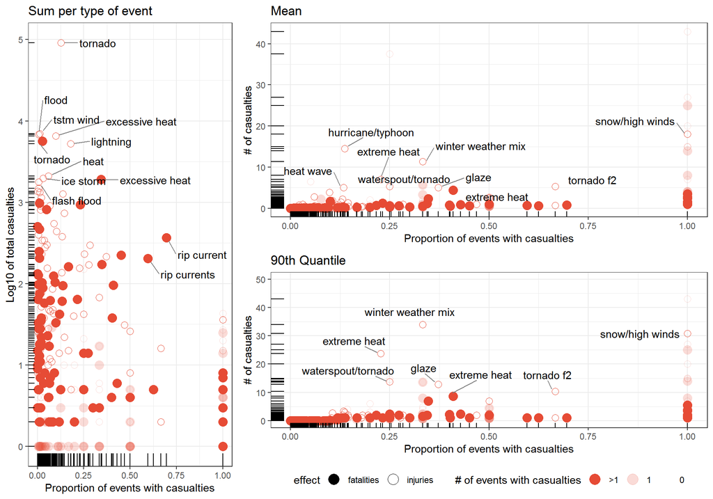

```r
multiplot(plot.health.sum,
          plot.health.mean,
          plot.health.q90,
          layout = matrix(c(1,2,2,1,3,3), nrow = 2, byrow = TRUE))
```

**Figure 1: Effect of event types on population health.** We show the total and mean amount of casualties an event type produced, as well as the 90th quantile of casualties for each event type. Filled circles correspond to fatalities, while the empty ones correspond to injuries. Transparent circles indicate that event type produced casualties only once and therefore correspond to extreme weather events (outliers). We omit event types that did not produce casualties. Margins of the graphs show rug plots, thus allowing for assesment of 1D distributions.

Interestingly, *90th quantile* graph clarifies that **extreme heat and cold** have a much higher effect on population health than do any other type of events, including tornadoes.

## 4.2 Event types and Economy

As for the population health, three graphs were produced when investigating the effect of event types on the economy. On the x-axis, they showed how often a specific type of event produces damage, while on the y-axes they show total and mean amount of damage the event types produced. In each case, we distinguished between property and crop (agricultural) damage. The third graph plots 90th quantile data, again to exclude unusually severe weather events.

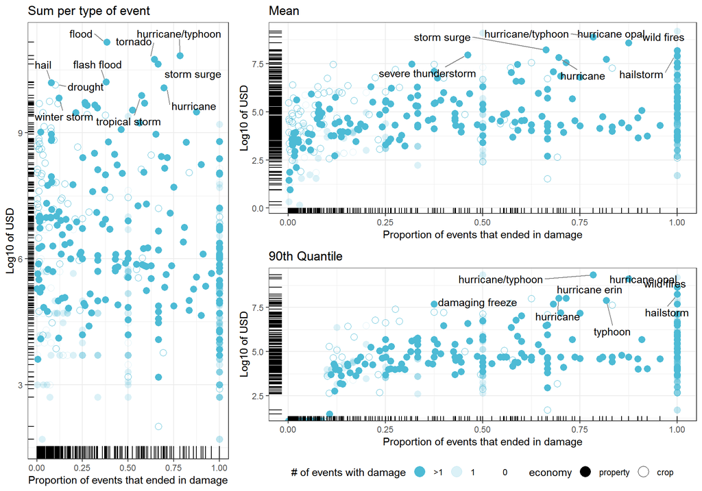

```r
multiplot(plot.damage.sum,
          plot.damage.mean,
          plot.damage.q90,
          layout = matrix(c(1,2,2,1,3,3), nrow = 2, byrow = TRUE))
```

**Figure 2: Effect of event types on the economy (material damage).** We show total and mean amount of damage an event type produced, as well as the 90th quantile of damage for each event type. Filled circles correspond to property damage, while the empty ones correspond to crop damage. Transparent circles indicate that event type damaged property or crops only once and therefore correspond to extreme weather events (outliers). We omit event types that did not produce damage. Margins of the graphs show rug plots, thus allowing for assesment of 1D distributions.

# 5 Conclusion

Event types that the most affect **population health** can be grouped into those that are caused by **extreme hot and cold** (e.g. extreme heat, snow/high winds) and to those that are caused by **severe storms** (e.g. hurricane/typhoon, tornadoes).

# 6 Addendum

Despite extensive classification instructions that NOAA uses, dataset suffers from vast inconsistencies. They vary from spelling differences (e.g. wild fires/wildfires) to improperly labelled events (e.g. extreme heat is not a valid event type, according to NOAA codebook). Subsequent analyses should be aware of this problem beforehand and perform extensive dataset check and cleaning.